# Fordgobike Data Exploration

## Preliminary Wrangling

This document explores a dataset describing fordgobike which is a regional public bicycle sharing system in San Francisco

```python
# import all packages and set plots to be embedded inline
import numpy as np
import pandas as pd
import matplotlib.pyplot as plt
import seaborn as sns

default_color = sns.color_palette()[0]
%matplotlib inline

import warnings
warnings.simplefilter("ignore")
```

```python
# load in the dataset into a pandas dataframe, print statistics
ford_df = pd.read_csv('201902-fordgobike-tripdata.csv')
```

```python
# high-level overview of data shape and composition
print(ford_df.shape)
print('='*100)
print(ford_df.dtypes)
print('='*100)
ford_df.head(10)
```

```
(183412, 16)
====================================================================================================
duration_sec                 int64
start_time                  object
end_time                    object
start_station_id           float64
start_station_name          object
start_station_latitude     float64
start_station_longitude    float64
end_station_id             float64
end_station_name            object
end_station_latitude       float64
end_station_longitude      float64
bike_id                      int64
user_type                   object
member_birth_year          float64
member_gender               object
bike_share_for_all_trip     object
dtype: object
====================================================================================================
```

|  | duration_sec | start_time | end_time | start_station_id | start_station_name | start_station_latitude | start_station_longitude | end_station_id | end_station_name | end_station_latitude | end_station_longitude | bike_id | user_type | member_birth_year | member_gender | bike_share_for_all_trip |
| --- | --- | --- | --- | --- | --- | --- | --- | --- | --- | --- | --- | --- | --- | --- | --- | --- |
| 0 | 52185 | 2019-02-28 17:32:10.1450 | 2019-03-01 08:01:55.9750 | 21.0 | Montgomery St BART Station (Market St at 2nd St) | 37.789625 | -122.400811 | 13.0 | Commercial St at Montgomery St | 37.794231 | -122.402923 | 4902 | Customer | 1984.0 | Male | No |
| 1 | 42521 | 2019-02-28 18:53:21.7890 | 2019-03-01 06:42:03.0560 | 23.0 | The Embarcadero at Steuart St | 37.791464 | -122.391034 | 81.0 | Berry St at 4th St | 37.775880 | -122.393170 | 2535 | Customer | NaN | NaN | No |
| 2 | 61854 | 2019-02-28 12:13:13.2180 | 2019-03-01 05:24:08.1460 | 86.0 | Market St at Dolores St | 37.769305 | -122.426826 | 3.0 | Powell St BART Station (Market St at 4th St) | 37.786375 | -122.404904 | 5905 | Customer | 1972.0 | Male | No |
| 3 | 36490 | 2019-02-28 17:54:26.0100 | 2019-03-01 04:02:36.8420 | 375.0 | Grove St at Masonic Ave | 37.774836 | -122.446546 | 70.0 | Central Ave at Fell St | 37.773311 | -122.444293 | 6638 | Subscriber | 1989.0 | Other | No |
| 4 | 1585 | 2019-02-28 23:54:18.5490 | 2019-03-01 00:20:44.0740 | 7.0 | Frank H Ogawa Plaza | 37.804562 | -122.271738 | 222.0 | 10th Ave at E 15th St | 37.792714 | -122.248780 | 4898 | Subscriber | 1974.0 | Male | Yes |
| 5 | 1793 | 2019-02-28 23:49:58.6320 | 2019-03-01 00:19:51.7600 | 93.0 | 4th St at Mission Bay Blvd S | 37.770407 | -122.391198 | 323.0 | Broadway at Kearny | 37.798014 | -122.405950 | 5200 | Subscriber | 1959.0 | Male | No |
| 6 | 1147 | 2019-02-28 23:55:35.1040 | 2019-03-01 00:14:42.5880 | 300.0 | Palm St at Willow St | 37.317298 | -121.884995 | 312.0 | San Jose Diridon Station | 37.329732 | -121.901782 | 3803 | Subscriber | 1983.0 | Female | No |
| 7 | 1615 | 2019-02-28 23:41:06.7660 | 2019-03-01 00:08:02.7560 | 10.0 | Washington St at Kearny St | 37.795393 | -122.404770 | 127.0 | Valencia St at 21st St | 37.756708 | -122.421025 | 6329 | Subscriber | 1989.0 | Male | No |
| 8 | 1570 | 2019-02-28 23:41:48.7900 | 2019-03-01 00:07:59.7150 | 10.0 | Washington St at Kearny St | 37.795393 | -122.404770 | 127.0 | Valencia St at 21st St | 37.756708 | -122.421025 | 6548 | Subscriber | 1988.0 | Other | No |
| 9 | 1049 | 2019-02-28 23:49:47.6990 | 2019-03-01 00:07:17.0250 | 19.0 | Post St at Kearny St | 37.788975 | -122.403452 | 121.0 | Mission Playground | 37.759210 | -122.421339 | 6488 | Subscriber | 1992.0 | Male | No |

## Our Dataset contains 183412 rows and 16 columns

```python
ford_df.describe()
```

|  | duration_sec | start_station_id | start_station_latitude | start_station_longitude | end_station_id | end_station_latitude | end_station_longitude | bike_id | member_birth_year |
| --- | --- | --- | --- | --- | --- | --- | --- | --- | --- |
| count | 183412.000000 | 183215.000000 | 183412.000000 | 183412.000000 | 183215.000000 | 183412.000000 | 183412.000000 | 183412.000000 | 175147.000000 |
| mean | 726.078435 | 138.590427 | 37.771223 | -122.352664 | 136.249123 | 37.771427 | -122.352250 | 4472.906375 | 1984.806437 |
| std | 1794.389780 | 111.778864 | 0.099581 | 0.117097 | 111.515131 | 0.099490 | 0.116673 | 1664.383394 | 10.116689 |
| min | 61.000000 | 3.000000 | 37.317298 | -122.453704 | 3.000000 | 37.317298 | -122.453704 | 11.000000 | 1878.000000 |
| 25% | 325.000000 | 47.000000 | 37.770083 | -122.412408 | 44.000000 | 37.770407 | -122.411726 | 3777.000000 | 1980.000000 |
| 50% | 514.000000 | 104.000000 | 37.780760 | -122.398285 | 100.000000 | 37.781010 | -122.398279 | 4958.000000 | 1987.000000 |
| 75% | 796.000000 | 239.000000 | 37.797280 | -122.286533 | 235.000000 | 37.797320 | -122.288045 | 5502.000000 | 1992.000000 |
| max | 85444.000000 | 398.000000 | 37.880222 | -121.874119 | 398.000000 | 37.880222 | -121.874119 | 6645.000000 | 2001.000000 |

```python
ford_df.info()
```

```
<class 'pandas.core.frame.DataFrame'>
RangeIndex: 183412 entries, 0 to 183411
Data columns (total 16 columns):
 #   Column                   Non-Null Count   Dtype
---  ------                   --------------   -----
 0   duration_sec             183412 non-null  int64
 1   start_time               183412 non-null  object
 2   end_time                 183412 non-null  object
 3   start_station_id         183215 non-null  float64
 4   start_station_name       183215 non-null  object
 5   start_station_latitude   183412 non-null  float64
 6   start_station_longitude  183412 non-null  float64
 7   end_station_id           183215 non-null  float64
 8   end_station_name         183215 non-null  object
 9   end_station_latitude     183412 non-null  float64
 10  end_station_longitude    183412 non-null  float64
 11  bike_id                  183412 non-null  int64
 12  user_type                183412 non-null  object
 13  member_birth_year        175147 non-null  float64
 14  member_gender            175147 non-null  object
 15  bike_share_for_all_trip  183412 non-null  object
dtypes: float64(7), int64(2), object(7)
memory usage: 22.4+ MB
```

```python
ford_df.isna().sum()
```

```
duration_sec                  0
start_time                    0
end_time                      0
start_station_id            197
start_station_name          197
start_station_latitude        0
start_station_longitude       0
end_station_id              197
end_station_name            197
end_station_latitude          0
end_station_longitude         0
bike_id                       0
user_type                     0
member_birth_year          8265
member_gender              8265
bike_share_for_all_trip       0
dtype: int64
```

## Nulls in our dataset in columns:

- start_station_id
- start_station_name
- end_station_id
- end_station_name
- member_birth_year
- member_gender

```python
ford_df.duplicated().sum()
```

```
0
```

## No Duplicates

```python
ford_df.head()
```

|  | duration_sec | start_time | end_time | start_station_id | start_station_name | start_station_latitude | start_station_longitude | end_station_id | end_station_name | end_station_latitude | end_station_longitude | bike_id | user_type | member_birth_year | member_gender | bike_share_for_all_trip |
| --- | --- | --- | --- | --- | --- | --- | --- | --- | --- | --- | --- | --- | --- | --- | --- | --- |
| 0 | 52185 | 2019-02-28 17:32:10.1450 | 2019-03-01 08:01:55.9750 | 21.0 | Montgomery St BART Station (Market St at 2nd St) | 37.789625 | -122.400811 | 13.0 | Commercial St at Montgomery St | 37.794231 | -122.402923 | 4902 | Customer | 1984.0 | Male | No |
| 1 | 42521 | 2019-02-28 18:53:21.7890 | 2019-03-01 06:42:03.0560 | 23.0 | The Embarcadero at Steuart St | 37.791464 | -122.391034 | 81.0 | Berry St at 4th St | 37.775880 | -122.393170 | 2535 | Customer | NaN | NaN | No |
| 2 | 61854 | 2019-02-28 12:13:13.2180 | 2019-03-01 05:24:08.1460 | 86.0 | Market St at Dolores St | 37.769305 | -122.426826 | 3.0 | Powell St BART Station (Market St at 4th St) | 37.786375 | -122.404904 | 5905 | Customer | 1972.0 | Male | No |
| 3 | 36490 | 2019-02-28 17:54:26.0100 | 2019-03-01 04:02:36.8420 | 375.0 | Grove St at Masonic Ave | 37.774836 | -122.446546 | 70.0 | Central Ave at Fell St | 37.773311 | -122.444293 | 6638 | Subscriber | 1989.0 | Other | No |
| 4 | 1585 | 2019-02-28 23:54:18.5490 | 2019-03-01 00:20:44.0740 | 7.0 | Frank H Ogawa Plaza | 37.804562 | -122.271738 | 222.0 | 10th Ave at E 15th St | 37.792714 | -122.248780 | 4898 | Subscriber | 1974.0 | Male | Yes |

```python
def plot_column_counts(col_name):
    print(ford_df[col_name].value_counts())
    _ = ford_df[col_name].value_counts().plot(kind='bar')
    _ = plt.title(f'{col_name} distribution')
    _ = plt.xlabel(f'{col_name} user_type')
    _ = plt.ylabel('count')
```

```
Subscriber    163544
Customer       19868
Name: user_type, dtype: int64
```

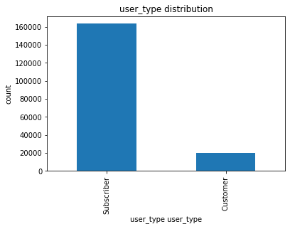

```python
plot_column_counts('user_type')
```

```
No     166053
Yes     17359
Name: bike_share_for_all_trip, dtype: int64
```

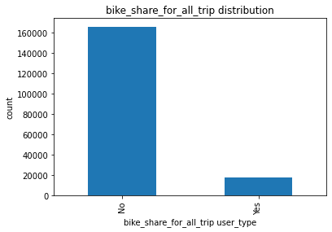

```python
plot_column_counts('bike_share_for_all_trip')
```

```
Male      130651
Female     40844
Other       3652
Name: member_gender, dtype: int64
```

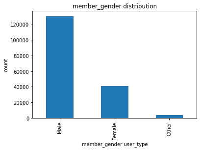

```python
plot_column_counts('member_gender')
```

## It seems there is unbalanced data for these columns:

- user_type
- bike_share_for_all_trip
- member_gender

# Data Cleaning

- Drop Null values as they are not high percentage
- Deal with data types transformations (start and end time)

```python
clean_df = ford_df.dropna()
```

```python
clean_df.isnull().sum()
```

```
duration_sec               0
start_time                 0
end_time                   0
start_station_id           0
start_station_name         0
start_station_latitude     0
start_station_longitude    0
end_station_id             0
end_station_name           0
end_station_latitude       0
end_station_longitude      0
bike_id                    0
user_type                  0
member_birth_year          0
member_gender              0
bike_share_for_all_trip    0
dtype: int64
```

```python
clean_df['start_time'] = pd.to_datetime(clean_df['start_time'])
clean_df['end_time'] = pd.to_datetime(clean_df['end_time'])
```

```python
clean_df.info()
```

```
<class 'pandas.core.frame.DataFrame'>
Int64Index: 174952 entries, 0 to 183411
Data columns (total 16 columns):
 #   Column                   Non-Null Count   Dtype
---  ------                   --------------   -----
 0   duration_sec             174952 non-null  int64
 1   start_time               174952 non-null  datetime64[ns]
 2   end_time                 174952 non-null  datetime64[ns]
 3   start_station_id         174952 non-null  float64
 4   start_station_name       174952 non-null  object
 5   start_station_latitude   174952 non-null  float64
 6   start_station_longitude  174952 non-null  float64
 7   end_station_id           174952 non-null  float64
 8   end_station_name         174952 non-null  object
 9   end_station_latitude     174952 non-null  float64
 10  end_station_longitude    174952 non-null  float64
 11  bike_id                  174952 non-null  int64
 12  user_type                174952 non-null  object
 13  member_birth_year        174952 non-null  float64
 14  member_gender            174952 non-null  object
 15  bike_share_for_all_trip  174952 non-null  object
dtypes: datetime64[ns](2), float64(7), int64(2), object(5)
memory usage: 22.7+ MB
```

## Extract features

- from start and end time as year & month & day of week & hour
- from member year of birth get age
- convert duration in seconds to minutes

```python
#from start and end time as month & day of week & hour
clean_df['start_day'] = clean_df['start_time'].dt.strftime('%A')
clean_df['start_month'] = clean_df['start_time'].dt.strftime('%B')
clean_df['start_hour'] = clean_df['start_time'].dt.strftime('%H')
```

```python
#from start and end time as year & month & day of week & hour
clean_df['end_day'] = clean_df['end_time'].dt.strftime('%A')
clean_df['end_month'] = clean_df['end_time'].dt.strftime('%B')
clean_df['end_hour'] = clean_df['end_time'].dt.strftime('%H')
```

```python
# member age and duration in minutes
start_year = clean_df['start_time'].dt.year[0]
clean_df['member_age'] = start_year - clean_df['member_birth_year']
clean_df['duration_minutes'] = clean_df['duration_sec']/60
clean_df['duration_minutes'] = clean_df['duration_minutes'].astype('int')
```

```python
clean_df.head()
```

|  | duration_sec | start_time | end_time | start_station_id | start_station_name | start_station_latitude | start_station_longitude | end_station_id | end_station_name | end_station_latitude | ... | member_gender | bike_share_for_all_trip | start_day | start_month | start_hour | end_day | end_month | end_hour | member_age | duration_minutes |
| --- | --- | --- | --- | --- | --- | --- | --- | --- | --- | --- | --- | --- | --- | --- | --- | --- | --- | --- | --- | --- | --- |
| 0 | 52185 | 2019-02-28 17:32:10.145 | 2019-03-01 08:01:55.975 | 21.0 | Montgomery St BART Station (Market St at 2nd St) | 37.789625 | -122.400811 | 13.0 | Commercial St at Montgomery St | 37.794231 | ... | Male | No | Thursday | February | 17 | Friday | March | 08 | 35.0 | 869 |
| 2 | 61854 | 2019-02-28 12:13:13.218 | 2019-03-01 05:24:08.146 | 86.0 | Market St at Dolores St | 37.769305 | -122.426826 | 3.0 | Powell St BART Station (Market St at 4th St) | 37.786375 | ... | Male | No | Thursday | February | 12 | Friday | March | 05 | 47.0 | 1030 |
| 3 | 36490 | 2019-02-28 17:54:26.010 | 2019-03-01 04:02:36.842 | 375.0 | Grove St at Masonic Ave | 37.774836 | -122.446546 | 70.0 | Central Ave at Fell St | 37.773311 | ... | Other | No | Thursday | February | 17 | Friday | March | 04 | 30.0 | 608 |
| 4 | 1585 | 2019-02-28 23:54:18.549 | 2019-03-01 00:20:44.074 | 7.0 | Frank H Ogawa Plaza | 37.804562 | -122.271738 | 222.0 | 10th Ave at E 15th St | 37.792714 | ... | Male | Yes | Thursday | February | 23 | Friday | March | 00 | 45.0 | 26 |
| 5 | 1793 | 2019-02-28 23:49:58.632 | 2019-03-01 00:19:51.760 | 93.0 | 4th St at Mission Bay Blvd S | 37.770407 | -122.391198 | 323.0 | Broadway at Kearny | 37.798014 | ... | Male | No | Thursday | February | 23 | Friday | March | 00 | 60.0 | 29 |

5 rows × 24 columns

```python
clean_df.info()
```

```
<class 'pandas.core.frame.DataFrame'>
Int64Index: 174952 entries, 0 to 183411
Data columns (total 24 columns):
 #   Column                   Non-Null Count   Dtype
---  ------                   --------------   -----
 0   duration_sec             174952 non-null  int64
 1   start_time               174952 non-null  datetime64[ns]
 2   end_time                 174952 non-null  datetime64[ns]
 3   start_station_id         174952 non-null  float64
 4   start_station_name       174952 non-null  object
 5   start_station_latitude   174952 non-null  float64
 6   start_station_longitude  174952 non-null  float64
 7   end_station_id           174952 non-null  float64
 8   end_station_name         174952 non-null  object
 9   end_station_latitude     174952 non-null  float64
```

[output cut: 16 more lines]

### What is/are the main feature(s) of interest in your dataset?

I'm most interested in figuring out what features are highly affecting the trip duration.

### What features in the dataset do you think will help support your investigation into your feature(s) of interest?

- Here are different features as:
- start_day,start_month, start_hour
- end_day,end_month, end_hour
- start/end_station_name
- start/end_station_latitude/longitude
- user_type
- member_age
- member_birth_year
- member_gender

## Univariate Exploration

I'll start by looking at the distribution of the individual variables

```python
def plot_hist(col_name, binsize=500):
    # plotting the histogram
    print(clean_df[col_name].describe())

    bins = np.arange(0, clean_df[col_name].max()+binsize, binsize)

    plt.figure(figsize=[8, 5])
    plt.hist(data = clean_df, x = col_name, bins = bins)
    plt.xlabel(col_name)
    plt.ylabel('Count')
    plt.title(f'{col_name} Distribution')
    plt.show()
```

```python
def plot_count(col_name):
    plt.figure(figsize=[8, 5])
    sns.countplot(data = clean_df, x = col_name, color = default_color)
    plt.title(f"{col_name} distribution")
    plt.show()
```

```python
def plot_scatter(col1, col2):
    plt.scatter(clean_df[col1], clean_df[col2], alpha = 0.2, marker='.');
    plt.title(f'Scatter plot for {col1} vs {col2}')
    plt.xlabel(col1)
    plt.ylabel(col2)
    plt.show()
```

```python
def plot_heatmap(col1, col2):
    plt.hist2d(data=clean_df, x=col1, y=col2);
    plt.colorbar();
    plt.title(f'Heatmap for {col1} vs {col2}')
    plt.xlabel(col1)
    plt.ylabel(col2)
    plt.show()
```

```
count    174952.000000
mean        704.002744
std        1642.204905
min          61.000000
25%         323.000000
50%         510.000000
75%         789.000000
max       84548.000000
Name: duration_sec, dtype: float64
```

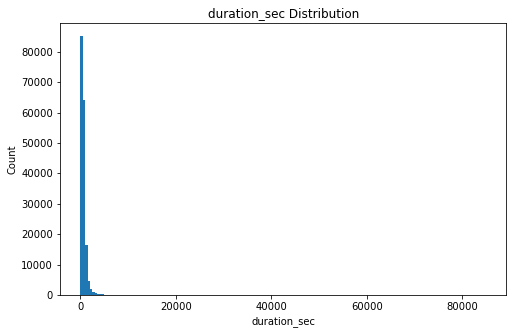

```python
plot_hist("duration_sec", binsize=500)
```

```
count    174952.000000
mean        704.002744
std        1642.204905
min          61.000000
25%         323.000000
50%         510.000000
75%         789.000000
max       84548.000000
Name: duration_sec, dtype: float64
```

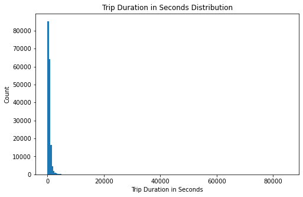

```python
# plotting the histogram of trip duration
print(clean_df['duration_sec'].describe())

binsize = 500
bins = np.arange(0, clean_df['duration_sec'].max()+binsize, binsize)

plt.figure(figsize=[8, 5])
plt.hist(data = clean_df, x = 'duration_sec', bins = bins)
plt.xlabel('Trip Duration in Seconds')
plt.ylabel('Count')
plt.title('Trip Duration in Seconds Distribution')
plt.show()
```

## The data is concentrated in the lower part, as we see min duration is 61 sec but max is 84548 so It is better to convert it to log scale

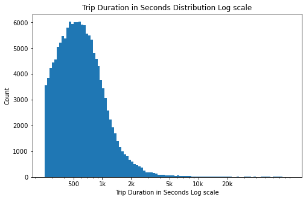

```python
# visualize trip duration sec in log scale
log_binsize = 0.025
bins = 10 ** np.arange(2.4, np.log10(clean_df['duration_sec'].max())+log_binsize, log_binsize)

plt.figure(figsize=[8, 5])
plt.hist(data = clean_df, x = 'duration_sec', bins = bins)
plt.xscale('log')
plt.xticks([500, 1e3, 2e3, 5e3, 1e4, 2e4], [500, '1k', '2k', '5k', '10k', '20k'])
plt.xlabel('Trip Duration in Seconds Log scale')
plt.ylabel('Count')
plt.title('Trip Duration in Seconds Distribution Log scale')
plt.show()
```

## It is clear that most data below 3k with one peak around at 500

```python
# Let's focus on the portion where most data occur in
clean_df = clean_df.query('duration_sec < 3000')
clean_df.shape
```

```
(173028, 24)
```

## member_age

```
count    173028.000000
mean         34.190015
std          10.109003
min          18.000000
25%          27.000000
50%          32.000000
75%          39.000000
max         141.000000
Name: member_age, dtype: float64
```

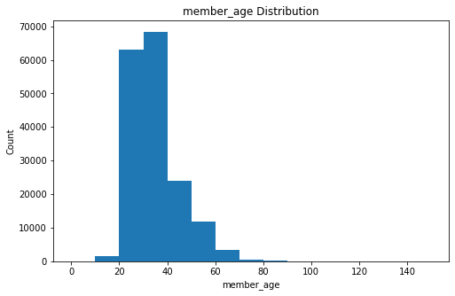

```python
plot_hist("member_age", binsize=10)
```

## It is clear that most values of age below 70 with peak at around 30

```python
# Let's focus on the portion where most data occur in
clean_df = clean_df.query('member_age < 70')
clean_df.shape
```

```
(172363, 24)
```

```
count    172363.000000
mean         34.011690
std           9.668181
min          18.000000
25%          27.000000
50%          32.000000
75%          39.000000
max          69.000000
Name: member_age, dtype: float64
```

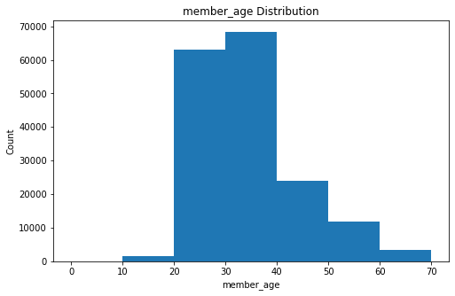

```python
plot_hist("member_age", binsize=10)
```

## Start and End stations

```
count    172363.000000
mean        138.820321
std         111.376077
min           3.000000
25%          47.000000
50%         104.000000
75%         239.000000
max         398.000000
Name: start_station_id, dtype: float64
```

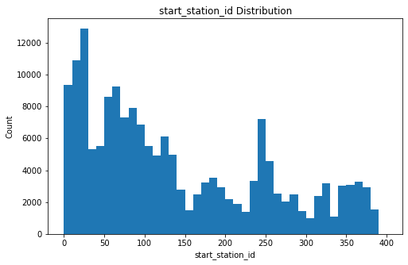

```python
plot_hist("start_station_id", binsize=10)
```

```
count    172363.000000
mean        136.273098
std         110.975015
min           3.000000
25%          44.000000
50%         101.000000
75%         235.000000
max         398.000000
Name: end_station_id, dtype: float64
```

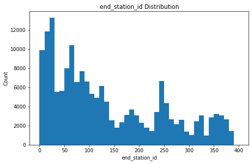

```python
plot_hist("end_station_id", binsize=10)
```

## Both Start & end stations have similar distributions, so stations are similar to be start or end station

## user_type

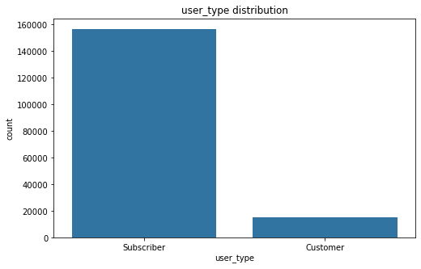

```python
plot_count('user_type')
```

## There is imbalance between user types, Most users are Subscriber

## member_gender

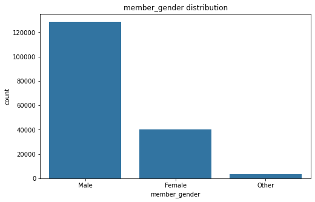

```python
plot_count('member_gender')
```

## Most users seem to be males, so there is bias in gender also

## start_day

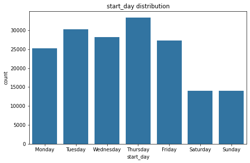

```python
plt.figure(figsize=[8, 5])

ORDER=['Monday', 'Tuesday', 'Wednesday', 'Thursday', 'Friday', 'Saturday', 'Sunday']

sns.countplot(data = clean_df, x = 'start_day', color = default_color, order=ORDER)
plt.title(f"{'start_day'} distribution")
plt.show()
```

## Week ends (saturday & sunday) Seems to be the least count

## end_day

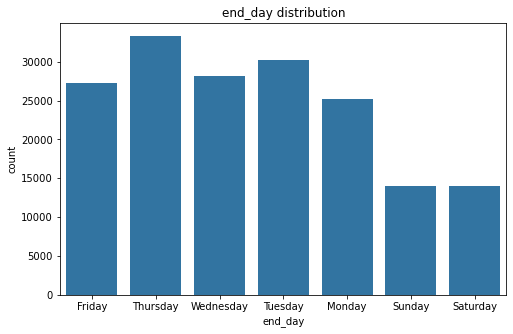

```python
plot_count('end_day')
```

## Week ends (saturday & sunday) Seems to be the least count also

## start_hour

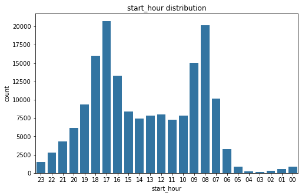

```python
plot_count('start_hour')
```

## There are two peaks at 8 am and 5 pm which are start and end of work hours

## end_hour

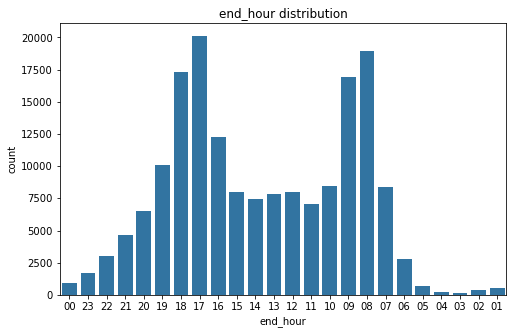

```python
plot_count('end_hour')
```

## Like start hour also There are two peaks at 8 am and 5 pm which are start and end of work hours

## bike_share_for_all_trip

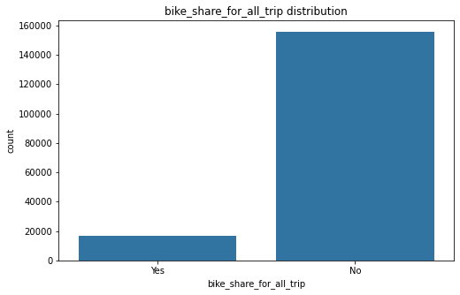

```python
plot_count('bike_share_for_all_trip')
```

## Most Users like not to share bike for all trip

### Discuss the distribution(s) of your variable(s) of interest. Were there any unusual points? Did you need to perform any transformations?

The trip duration has a huge amount of values with large distributions from 61 seconds to 84548, most of them are in the lower part. so I used log scale to generate a better visualization and remove outliers.

## Bivariate Exploration

To start off with, I want to look at the pairwise correlations present between features in the data.

```python
clean_df.columns
```

```
Index(['duration_sec', 'start_time', 'end_time', 'start_station_id',
       'start_station_name', 'start_station_latitude',
       'start_station_longitude', 'end_station_id', 'end_station_name',
       'end_station_latitude', 'end_station_longitude', 'bike_id', 'user_type',
       'member_birth_year', 'member_gender', 'bike_share_for_all_trip',
       'start_day', 'start_month', 'start_hour', 'end_day', 'end_month',
       'end_hour', 'member_age', 'duration_minutes'],
      dtype='object')
```

```python
clean_df.info()
```

```
<class 'pandas.core.frame.DataFrame'>
Int64Index: 172363 entries, 4 to 183411
Data columns (total 24 columns):
 #   Column                   Non-Null Count   Dtype
---  ------                   --------------   -----
 0   duration_sec             172363 non-null  int64
 1   start_time               172363 non-null  datetime64[ns]
 2   end_time                 172363 non-null  datetime64[ns]
 3   start_station_id         172363 non-null  float64
 4   start_station_name       172363 non-null  object
 5   start_station_latitude   172363 non-null  float64
 6   start_station_longitude  172363 non-null  float64
 7   end_station_id           172363 non-null  float64
 8   end_station_name         172363 non-null  object
 9   end_station_latitude     172363 non-null  float64
```

[output cut: 16 more lines]

```python
categoric_cols = [col for col in clean_df.columns if clean_df[col].dtype == "object"]
datetime_cols = [col for col in clean_df.columns if clean_df[col].dtype == "datetime64[ns]"]
numeric_cols = [col for col in clean_df.columns if col not in categoric_cols and col not in datetime_cols]
len(numeric_cols) + len(categoric_cols) + len(datetime_cols)
```

```
24
```

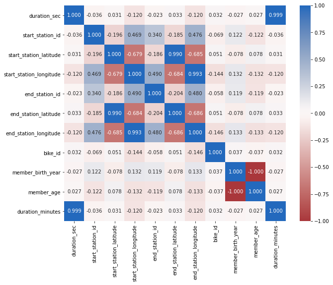

```python
# correlation plot
plt.figure(figsize = [10, 8])
sns.heatmap(clean_df[numeric_cols].corr(), annot = True, fmt = '.3f',
           cmap = 'vlag_r', center = 0)
plt.show()
```

## From Correlation Matrix:

- member_birth_year highly negatively correlated with member_age
- start_station_id positively correlated with start_station_longitude
- start_station_lattitude negatively correlated with start_station_longitude
- end_station_lattitude negatively correlated with end_station_longitude

## duration with age

```python
clean_df.columns
```

```
Index(['duration_sec', 'start_time', 'end_time', 'start_station_id',
       'start_station_name', 'start_station_latitude',
       'start_station_longitude', 'end_station_id', 'end_station_name',
       'end_station_latitude', 'end_station_longitude', 'bike_id', 'user_type',
       'member_birth_year', 'member_gender', 'bike_share_for_all_trip',
       'start_day', 'start_month', 'start_hour', 'end_day', 'end_month',
       'end_hour', 'member_age', 'duration_minutes'],
      dtype='object')
```

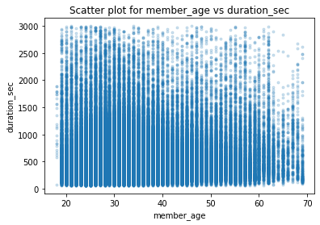

```python
plot_scatter('member_age', 'duration_sec')
```

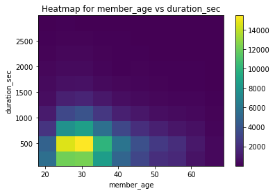

```python
plot_heatmap('member_age', 'duration_sec')
```

## It seems that users between 25 to 35 age have trips with duration frequent low and high durations

## duration with gender

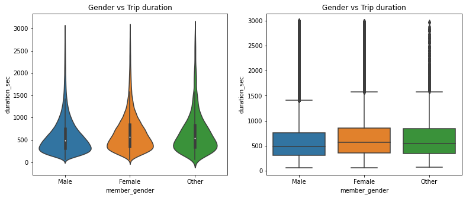

```python
plt.figure(figsize = [13, 5])

plt.subplot(1, 2, 1)
plt.title('Gender vs Trip duration')
sns.violinplot(data=clean_df, x='member_gender', y='duration_sec');
plt.subplot(1, 2, 2)
plt.title('Gender vs Trip duration')
sns.boxplot(data=clean_df, x='member_gender', y='duration_sec');
plt.show()
```

## It seems that All genders have nearly the same duration distribution But The median value for female is slightly higher than male and other

## duration with user_type

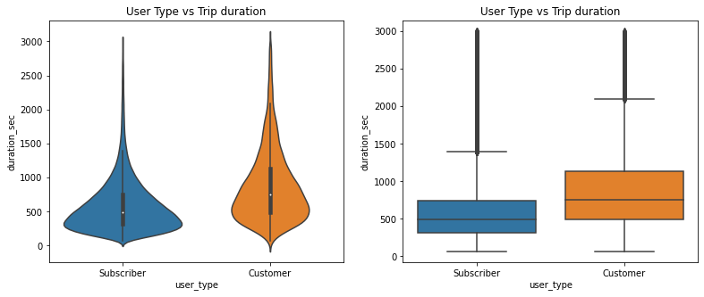

```python
plt.figure(figsize = [13, 5])

plt.subplot(1, 2, 1)
plt.title('User Type vs Trip duration')
sns.violinplot(data=clean_df, x='user_type', y='duration_sec');
plt.subplot(1, 2, 2)
plt.title('User Type vs Trip duration')
sns.boxplot(data=clean_df, x='user_type', y='duration_sec');
plt.show()
```

## It is clear the on average customers have longer trips than subscribers

## start station with duration

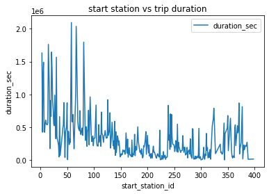

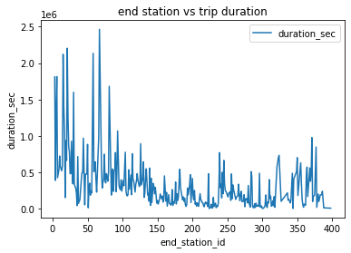

```python
_ = plt.figure(figsize = [13, 5])

_ = clean_df.groupby('start_station_id').sum().reset_index().plot(x='start_station_id', y='duration_sec')
_ = plt.xlabel('start_station_id')
_ = plt.ylabel('duration_sec')
_ = plt.title('start station vs trip duration')

_ = clean_df.groupby('end_station_id').sum().reset_index().plot(x='end_station_id', y='duration_sec')
_ = plt.xlabel('end_station_id')
_ = plt.ylabel('duration_sec')
_ = plt.title('end station vs trip duration')

plt.show()
```

### Did you observe any interesting relationships between the other features (not the main feature(s) of interest)?

Yes, from our correlation matrix

- member_birth_year highly negatively correlated with member_age
- start_station_id positively correlated with start_station_longitude
- start_station_lattitude negatively correlated with start_station_longitude
- end_station_lattitude negatively correlated with end_station_longitude
- also females tend to have slightly higher duration than males

## Multivariate Exploration

The main thing I want to explore in this part of the analysis of three or more variables to investigate data even further.

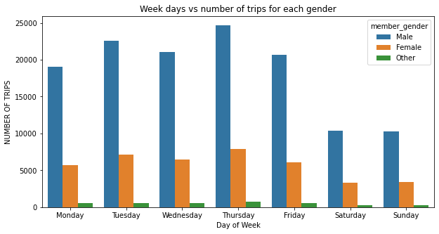

```python
fig=plt.figure(figsize=(10,5))
ORDER=['Monday', 'Tuesday', 'Wednesday', 'Thursday', 'Friday', 'Saturday', 'Sunday']

sns.countplot(data=clean_df, x='start_day', hue='member_gender', order=ORDER)
plt.xlabel('Day of Week')
plt.ylabel('NUMBER OF TRIPS')
plt.title('Week days vs number of trips for each gender');
```

## It seems that Males and females tend to have lower trips on weekends

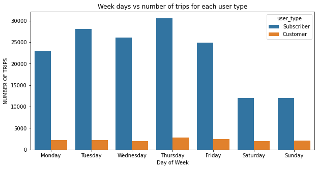

```python
fig=plt.figure(figsize=(10,5))
ORDER=['Monday', 'Tuesday', 'Wednesday', 'Thursday', 'Friday', 'Saturday', 'Sunday']

sns.countplot(data=clean_df, x='start_day', hue='user_type', order=ORDER)
plt.xlabel('Day of Week')
plt.ylabel('NUMBER OF TRIPS')
plt.title('Week days vs number of trips for each user type');
```

## It seems that Subscriber users also have lower trips on week ends But for Customer users all days tend to be the same

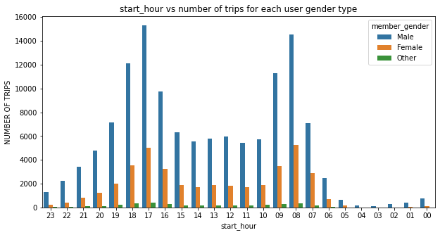

```python
fig=plt.figure(figsize=(10,5))

sns.countplot(data=clean_df, x='start_hour', hue='member_gender')
plt.xlabel('start_hour')
plt.ylabel('NUMBER OF TRIPS')
plt.title('start_hour vs number of trips for each user gender type');
```

## It seems that also that Males and females have top number of trips at 17 and 8 hours due to work hours

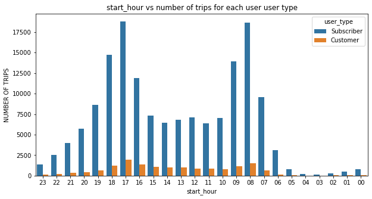

```python
fig=plt.figure(figsize=(10,5))

sns.countplot(data=clean_df, x='start_hour', hue='user_type')
plt.xlabel('start_hour')
plt.ylabel('NUMBER OF TRIPS')
plt.title('start_hour vs number of trips for each user user type');
```

## It seems that also that Subscriber users also have top number of trips at 17 and 8 hours due to work hours. But customer users slightly difference in most hours except from 23 to 6 the trips are very rare

## Trip duration with member_gender

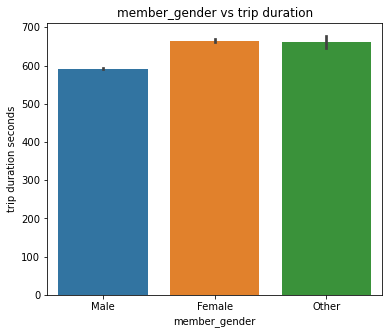

```python
fig=plt.figure(figsize=(6,5))

sns.barplot(data = clean_df, x = 'member_gender', y = 'duration_sec');
plt.xlabel('member_gender')
plt.ylabel('trip duration seconds')
plt.title('member_gender vs trip duration');
```

## It seems that females have trip duration more than males

## Trip duration with user_type

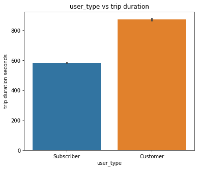

```python
fig=plt.figure(figsize=(6,5))

sns.barplot(data = clean_df, x = 'user_type', y = 'duration_sec');
plt.xlabel('user_type')
plt.ylabel('trip duration seconds')
plt.title('user_type vs trip duration');
```

## It seems that Customers have trip duration more than Subscribers

## Age with duration for each day

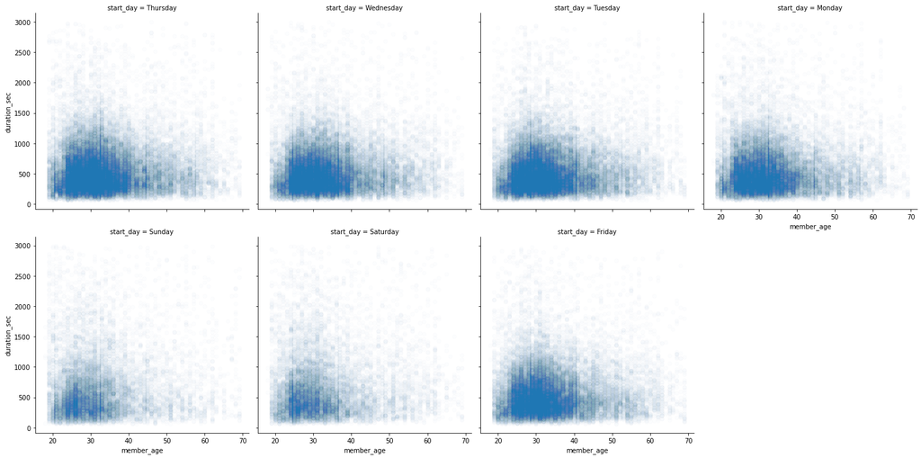

```python
FacetGrid = sns.FacetGrid(data=clean_df, col='start_day', col_wrap=4, height=5);
FacetGrid.map(plt.scatter, 'member_age', 'duration_sec', alpha=0.01);
```

## It seems ages around from 20 to 40 years who are at working age have most of trips

### Talk about some of the relationships you observed in this part of the investigation. Were there features that strengthened each other in terms of looking at your feature(s) of interest?

- Males and females tend to have lower trips on weekends
- Subscriber users also have lower trips on week ends But for Customer users all days tend to be the same
- Males and females have top number of trips at 17 and 8 hours due to work hours
- Subscriber users also have top number of trips at 17 and 8 hours due to work hours. But customer users slightly difference in most hours except from 23 to 6 the trips are very rare
- females have trip duration more than males
- Customers have trip duration more than Subscribers
- ages around from 20 to 40 years who are at working age have most of trips

### Were there any interesting or surprising interactions between features?

- It was surprising that females have trip duration more than males